# Exploratory Data Analysis Report

## Exploratory Data analysis (EDA)

Analyzing the data sets to summarize their main characteristics of variables, often with visual graphs, without using a statistical model.

### 1. Overview of the data

Understanding the dimensions of the dataset, variable names, overall missing summary and data types of each variables

```r
# Overview of the data
ExpData(data=data,type=1)
# Structure of the data
ExpData(data=data,type=2)
```

**Overview of the data**

| Descriptions | Value |
| --- | --- |
| Sample size (nrow) | 257 |
| No. of variables (ncol) | 10 |
| No. of numeric/interger variables | 8 |
| No. of factor variables | 0 |
| No. of text variables | 2 |
| No. of logical variables | 0 |
| No. of identifier variables | 1 |
| No. of date variables | 0 |
| No. of zero variance variables (uniform) | 0 |
| %. of variables having complete cases | 100% (10) |

[output cut: 3 more lines]

**Structure of the data**

| Index | Variable_Name | Variable_Type | Sample_n | Missing_Count | Per_of_Missing | No_of_distinct_values |
| --- | --- | --- | --- | --- | --- | --- |
| 1 | date | character | 257 | 0 | 0 | 257 |
| 2 | all | numeric | 257 | 0 | 0 | 238 |
| 3 | female | numeric | 257 | 0 | 0 | 243 |
| 4 | male | integer | 257 | 0 | 0 | 243 |
| 5 | young | integer | 257 | 0 | 0 | 238 |
| 6 | adult | numeric | 257 | 0 | 0 | 242 |
| 7 | weather | character | 257 | 0 | 0 | 2 |
| 8 | maxtemp | integer | 257 | 0 | 0 | 23 |
| 9 | RH | integer | 257 | 0 | 0 | 65 |
| 10 | maxwind | integer | 257 | 0 | 0 | 26 |

**Target variable**

### 2. Summary of numerical variables

Summary statistics when dependent variable is Continuous **all**.

```r
ExpNumStat(data,by="A",gp=Target,Qnt=seq(0,1,0.1),MesofShape=2,Outlier=TRUE,round=2)
```

| Vname | Group | Note | TN | nNeg | nZero | nPos | NegInf | PosInf | NA_Value | Per_of_Missing | sum | min | max | mean | median | SD | CV | IQR | Skewness | Kurtosis | 0% | 10% | 20% | 30% | 40% | 50% | 60% | 70% | 80% | … |
| --- | --- | --- | --- | --- | --- | --- | --- | --- | --- | --- | --- | --- | --- | --- | --- | --- | --- | --- | --- | --- | --- | --- | --- | --- | --- | --- | --- | --- | --- | --- |
| adult | all | Cor b/w all | 257 | 0 | 0 | 257 | 0 | 0 | 0 | 0 | 513975 | 184 | 8240 | 1999.90 | 2021 | 854.90 | 0.43 | 916 | 2.30 | 12.16 | 184 | 1114.4 | 1362.4 | 1510.2 | 1798.0 | 2021 | 2130.6 | 2282.8 | 2417.8 | … |
| all | all | Cor b/w all | 257 | 0 | 0 | 257 | 0 | 0 | 0 | 0 | 937617 | 375 | 15735 | 3648.32 | 3643 | 1625.59 | 0.45 | 1745 | 2.48 | 13.37 | 375 | 2049.6 | 2371.8 | 2681.6 | 3269.6 | 3643 | 3844.6 | 4120.8 | 4434.6 | … |
| female | all | Cor b/w all | 257 | 0 | 0 | 257 | 0 | 0 | 0 | 0 | 436333 | 194 | 7645 | 1697.79 | 1725 | 803.60 | 0.47 | 896 | 2.29 | 12.35 | 194 | 859.4 | 1029.4 | 1208.2 | 1428.6 | 1725 | 1811.0 | 1975.0 | 2154.2 | … |
| male | all | Cor b/w all | 257 | 0 | 0 | 257 | 0 | 0 | 0 | 0 | 456419 | 170 | 7045 | 1775.95 | 1755 | 748.15 | 0.42 | 730 | 2.34 | 11.54 | 170 | 1029.6 | 1229.4 | 1386.0 | 1579.8 | 1755 | 1877.6 | 1988.4 | 2153.6 | … |
| maxtemp | all | Cor b/w all | 257 | 0 | 0 | 257 | 0 | 0 | 0 | 0 | 4777 | 7 | 32 | 18.59 | 19 | 5.23 | 0.28 | 6 | 0.01 | -0.48 | 7 | 11.0 | 14.0 | 16.0 | 17.0 | 19 | 20.0 | 22.0 | 23.0 | … |
| maxwind | all | Cor b/w all | 257 | 0 | 104 | 153 | 0 | 0 | 0 | 0 | 6413 | 0 | 74 | 24.95 | 32 | 22.18 | 0.89 | 42 | 0.05 | -1.40 | 0 | 0.0 | 0.0 | 0.0 | 0.0 | 32 | 35.0 | 40.0 | 47.0 | … |
| RH | all | Cor b/w all | 257 | 0 | 0 | 257 | 0 | 0 | 0 | 0 | 17278 | 24 | 99 | 67.23 | 69 | 15.85 | 0.24 | 21 | -0.50 | -0.21 | 24 | 42.6 | 54.0 | 62.0 | 67.0 | 69 | 72.0 | 75.0 | 81.0 | … |
| young | all | Cor b/w all | 257 | 0 | 0 | 257 | 0 | 0 | 0 | 0 | 423642 | 191 | 7495 | 1648.41 | 1625 | 792.73 | 0.48 | 820 | 2.63 | 14.11 | 191 | 862.8 | 1035.6 | 1186.4 | 1442.0 | 1625 | 1731.0 | 1849.6 | 2057.0 | … |

### 3. Distributions of numerical variables

Graphical representation of all numeric features, used below types of plots to explore the data

- Quantile-quantile plot (Univariate)
- Density plot (Univariate)
- Scatter plot (Bivariate)

#### Quantile-quantile plot for Numerical variables - Univariate

Quantile-quantile plot for all Numerical variables

```r
ExpOutQQ(data,nlim=4,fname=NULL,Page=c(2,2),sample=sn)
```

```
## $`0`
```

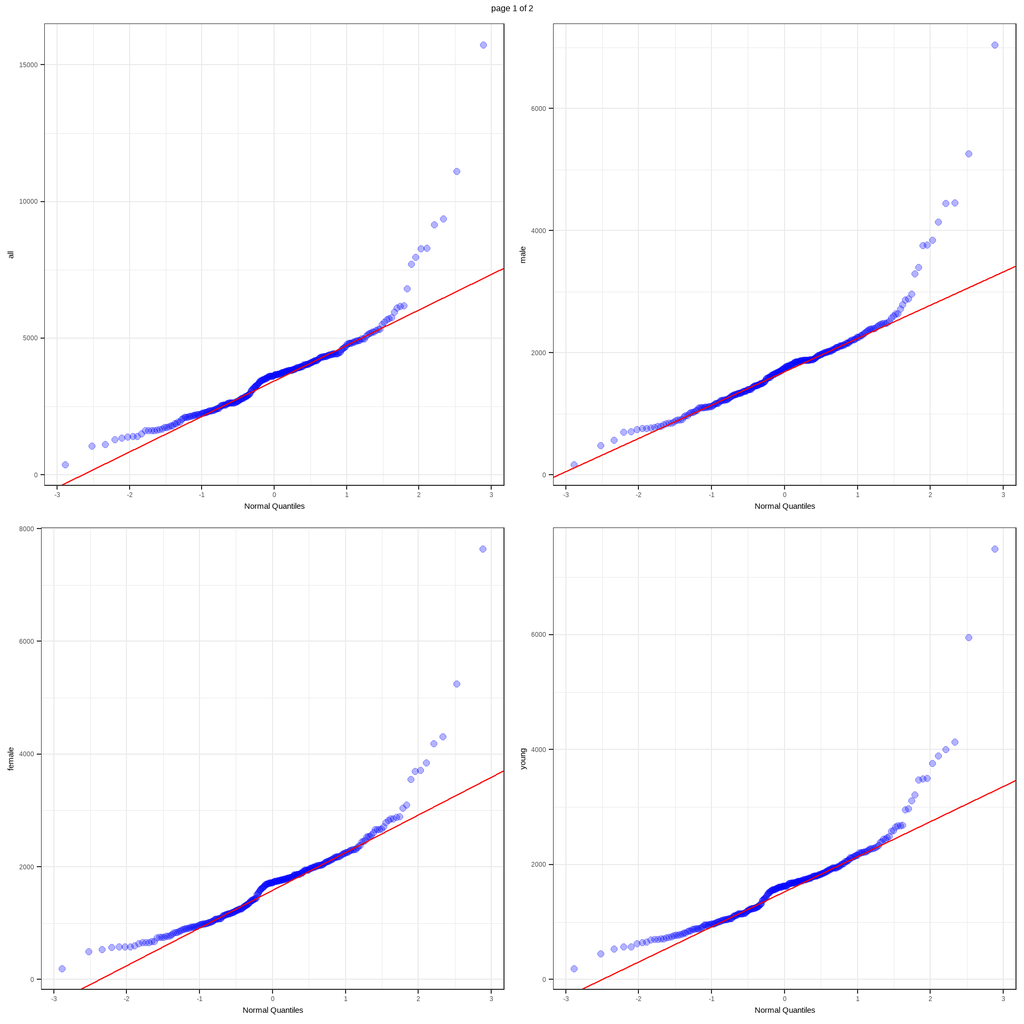

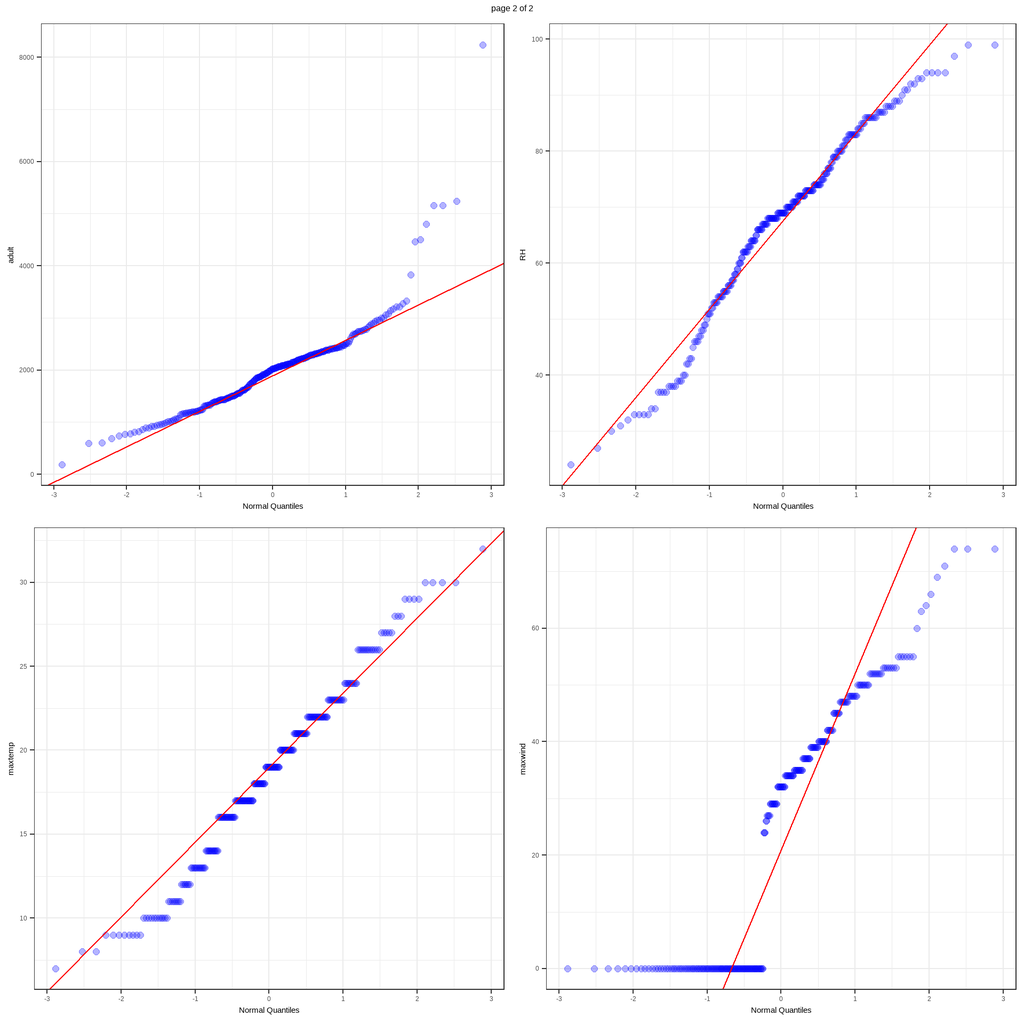

#### Density plots for numerical variables - Univariate

Density plot for all numerical variables

```
## $`0`
```

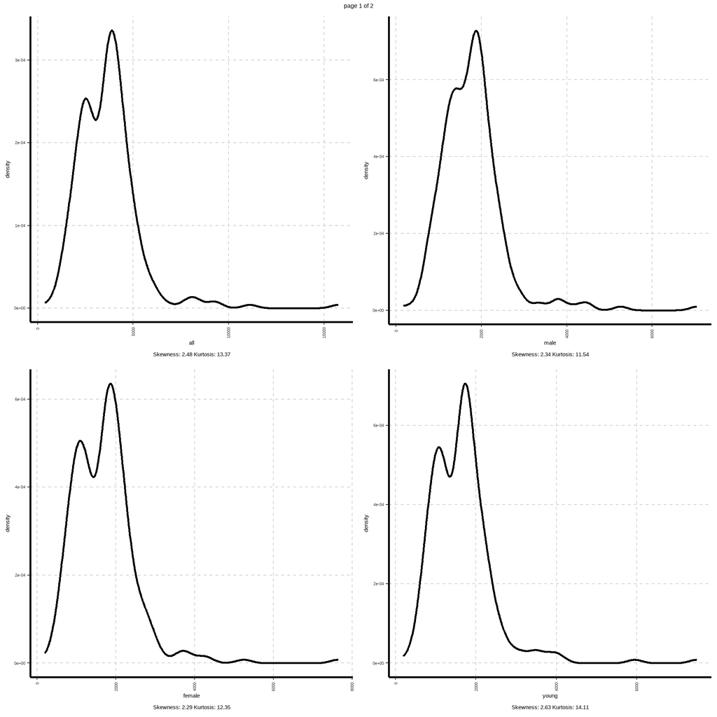

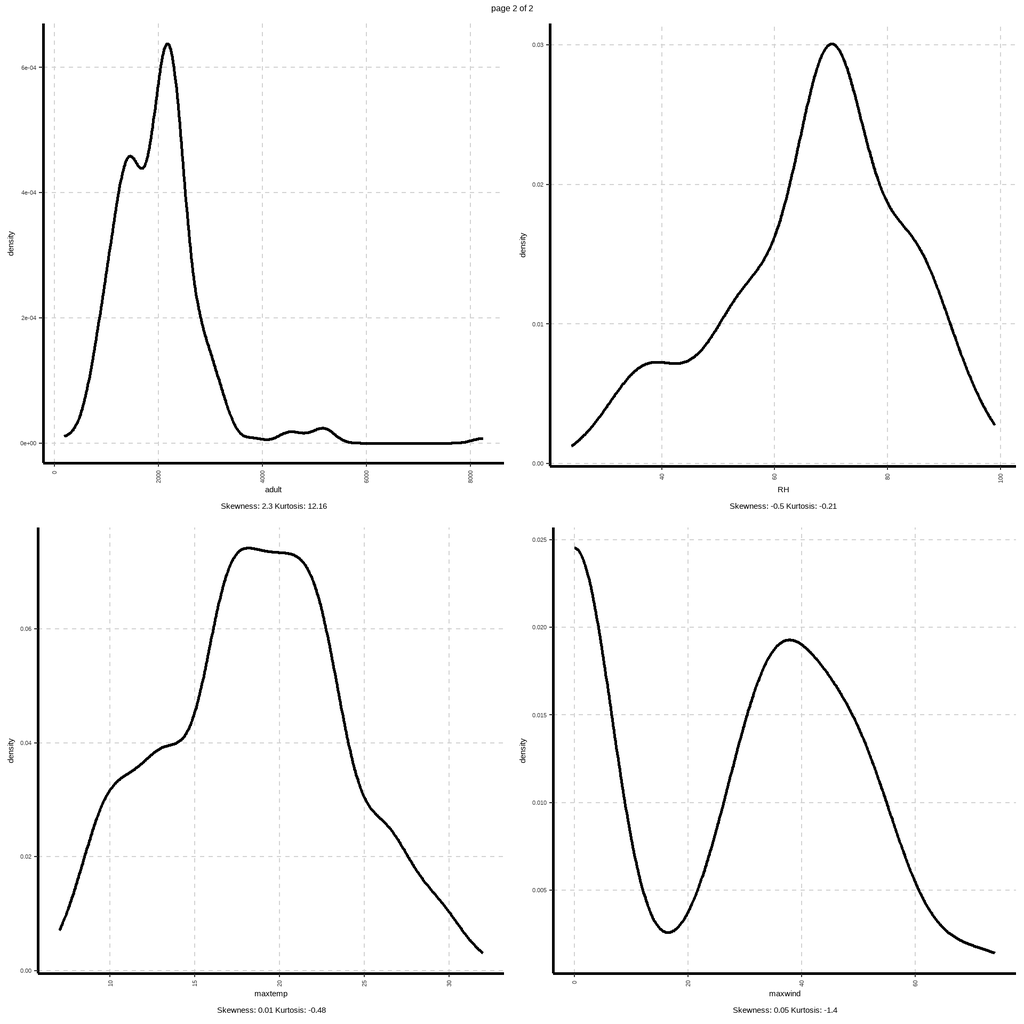

```r
ExpNumViz(data,target=NULL,nlim=10,fname=NULL,col=NULL,theme=theme,Page=c(2,2),sample=sn)
```

#### Scatter plot for all Numeric variables

```
## $`0`
```

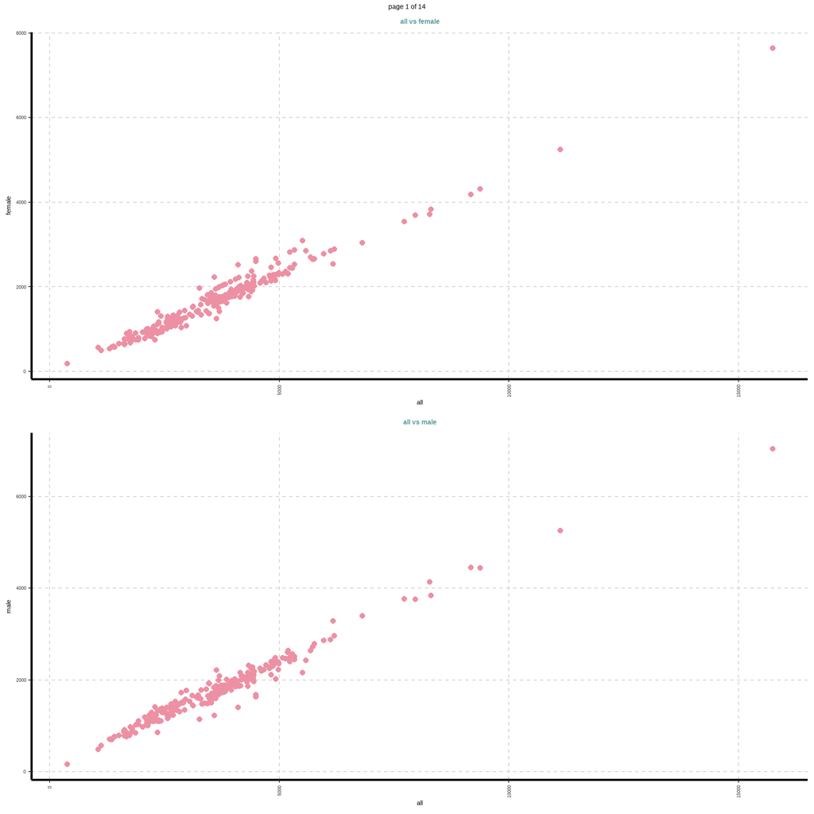

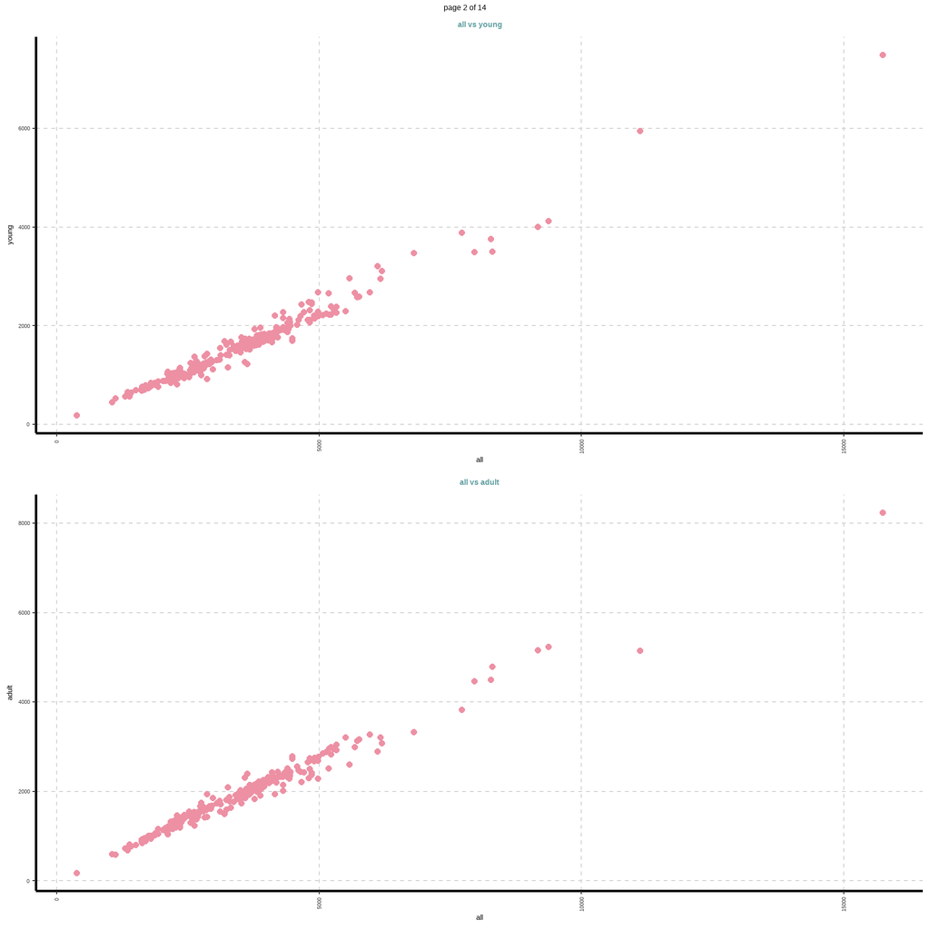

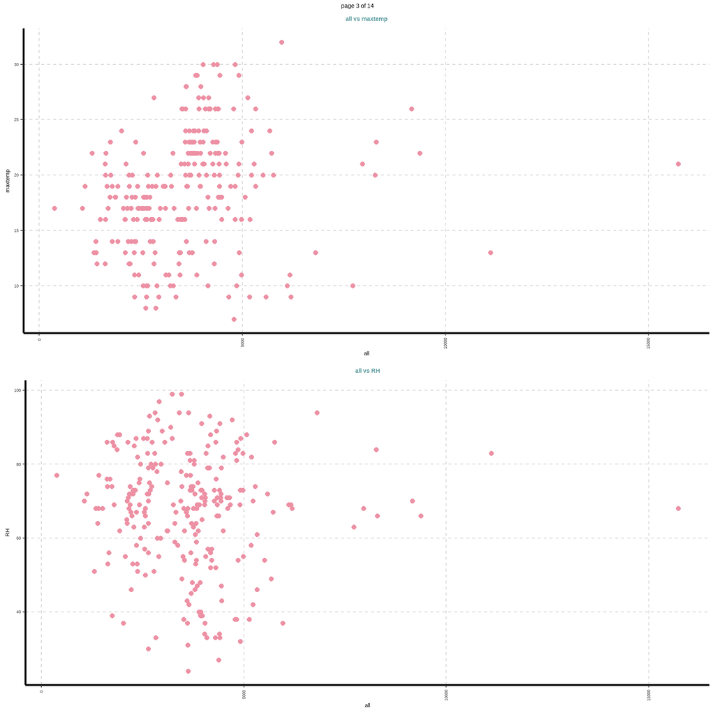

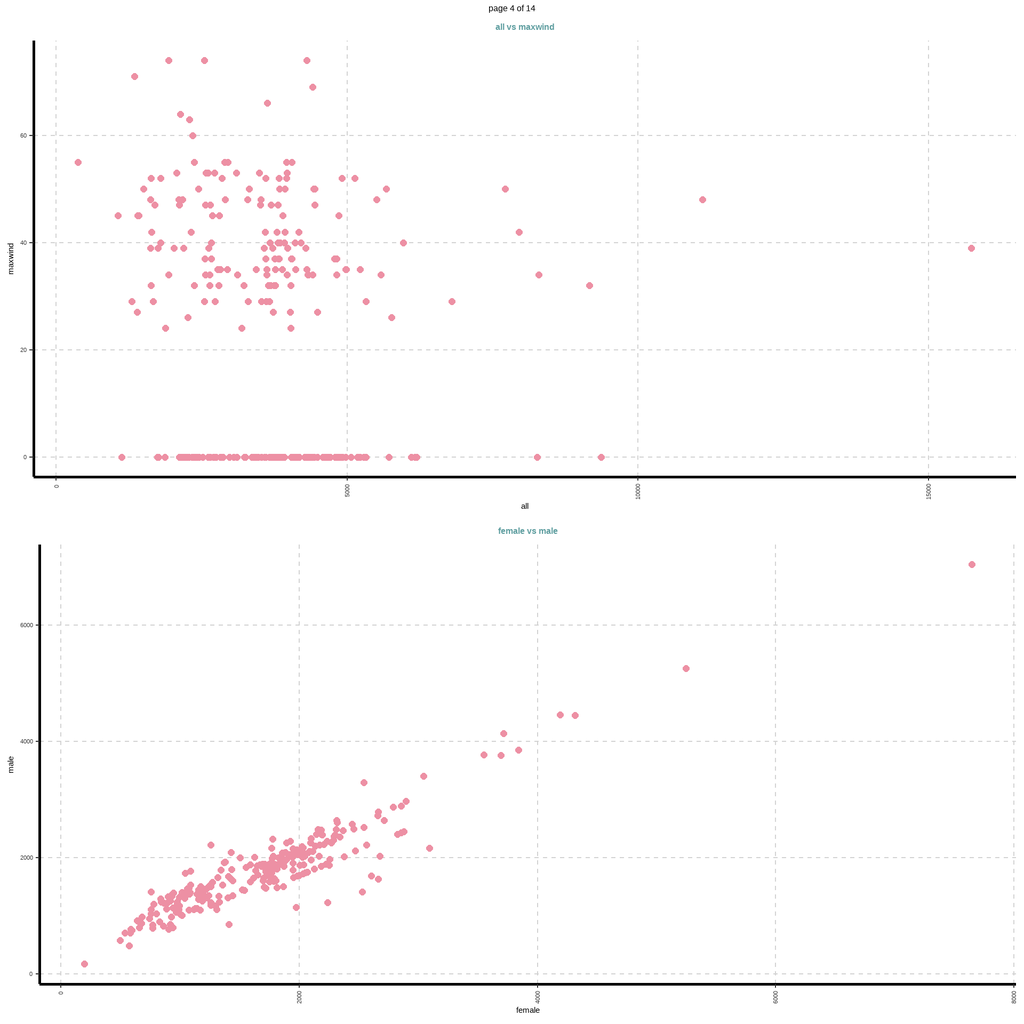

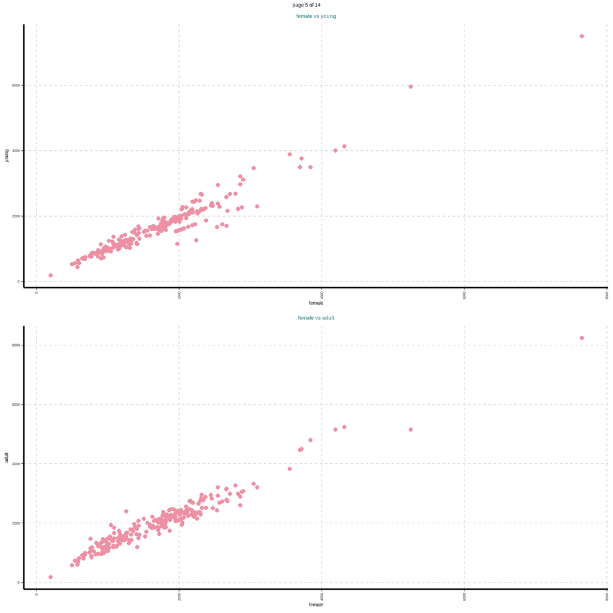

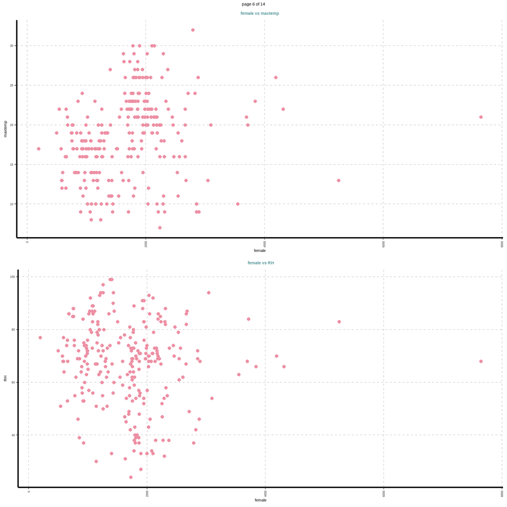

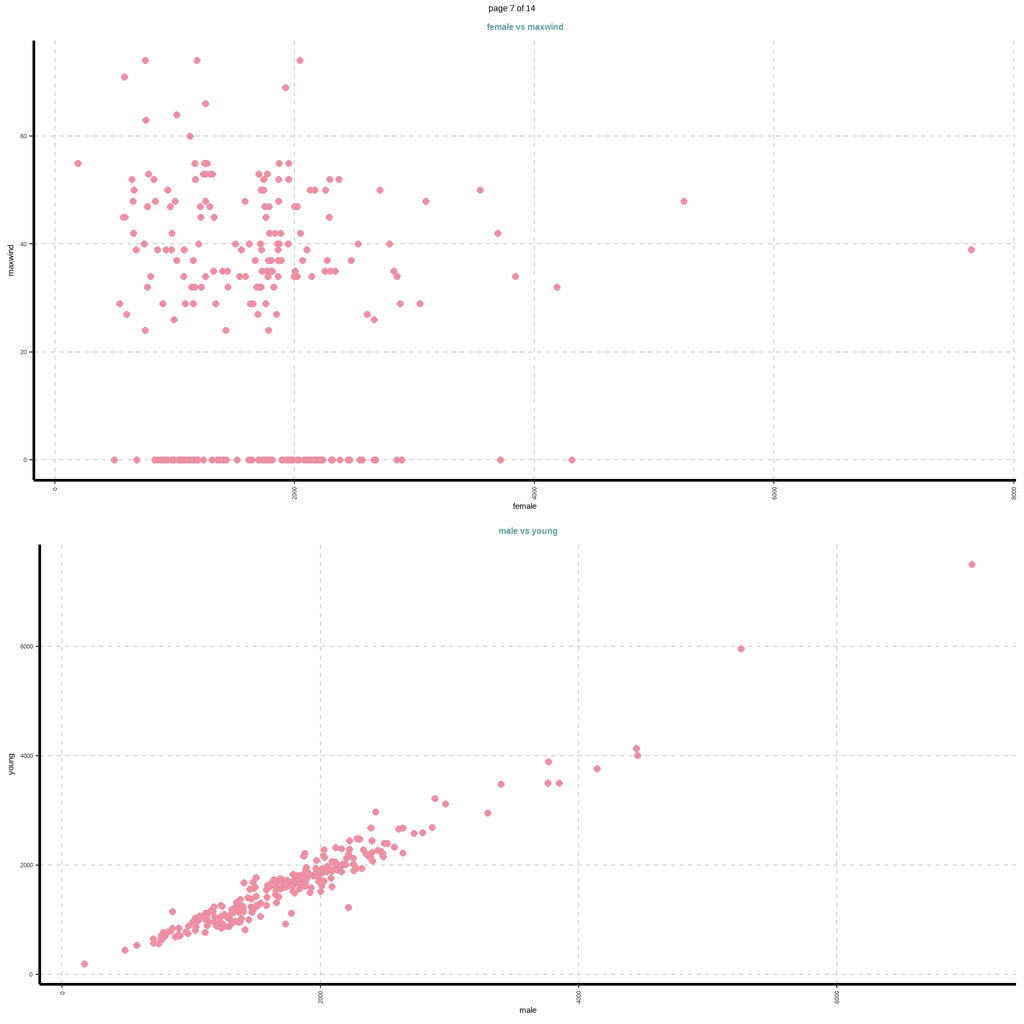

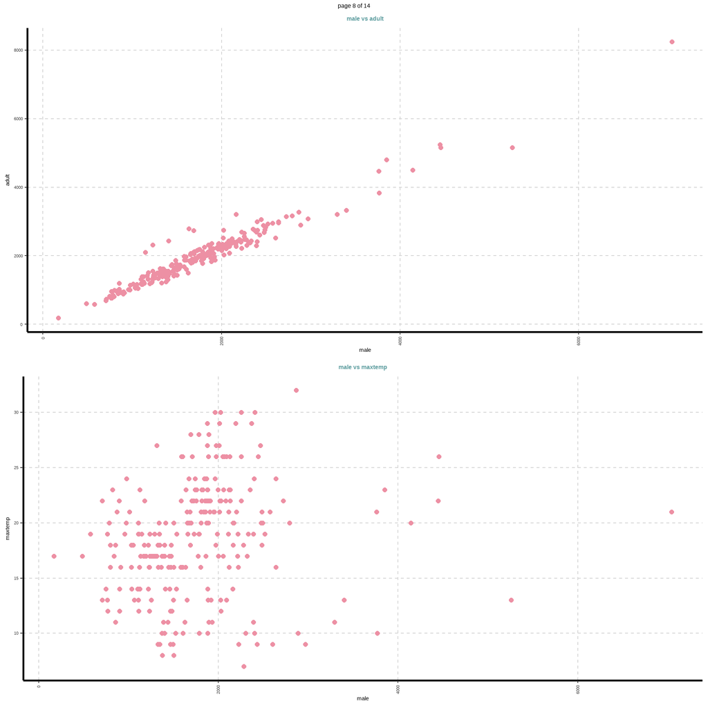

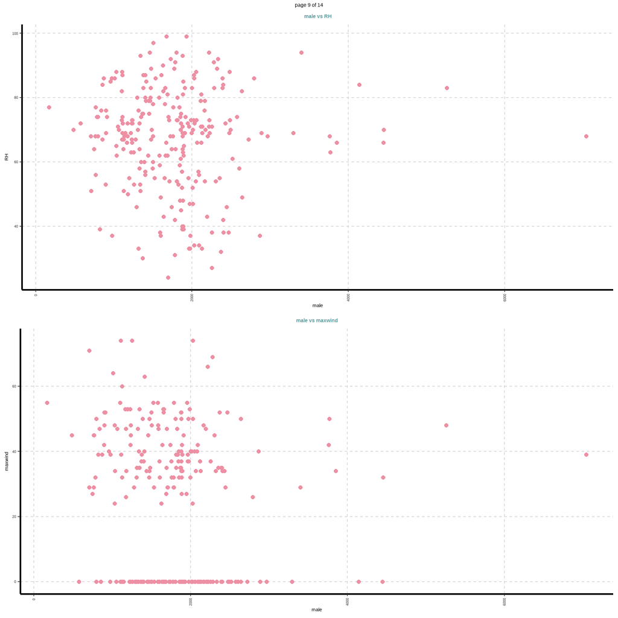

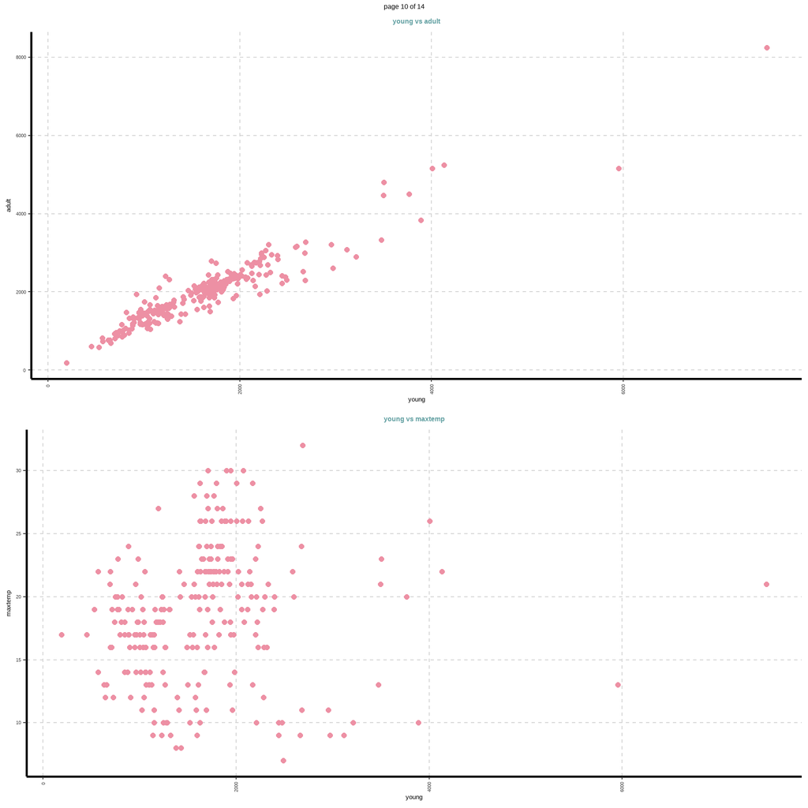

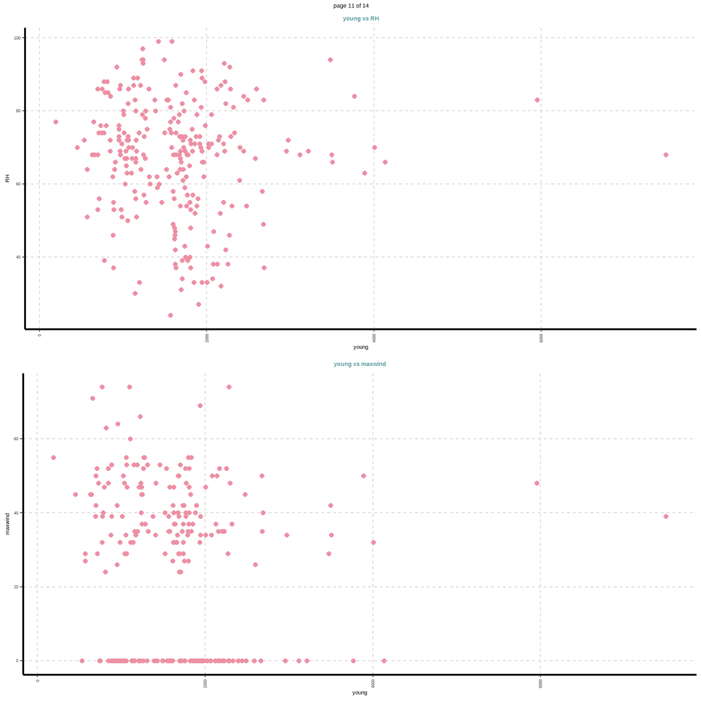

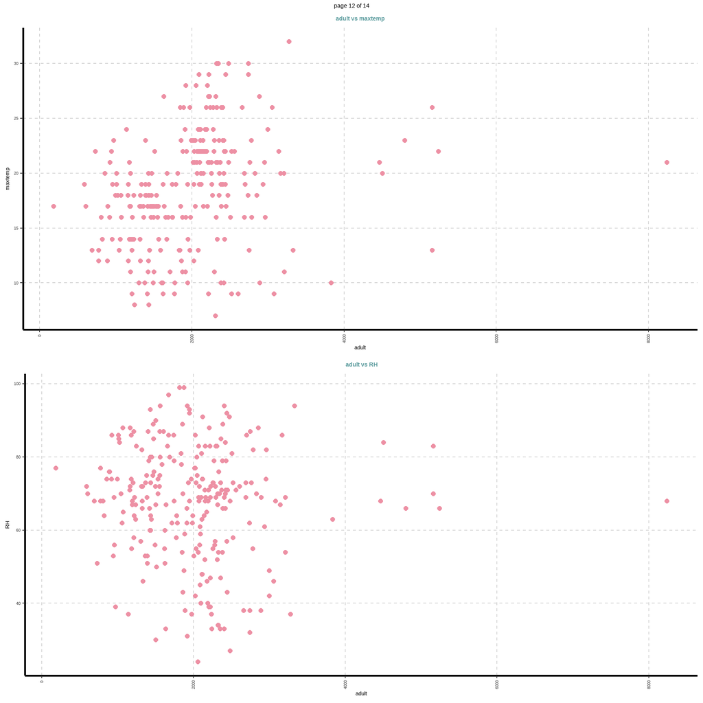

[2 more figures not shown]

```r
ExpNumViz(data,target=NULL,nlim=5,Page=c(2,1),theme=theme,sample=sn,scatter=TRUE)
```

#### Correlation between dependent variable vs Independent variables

Dependent variable is **all** (continuous).

```
## $`0`
```

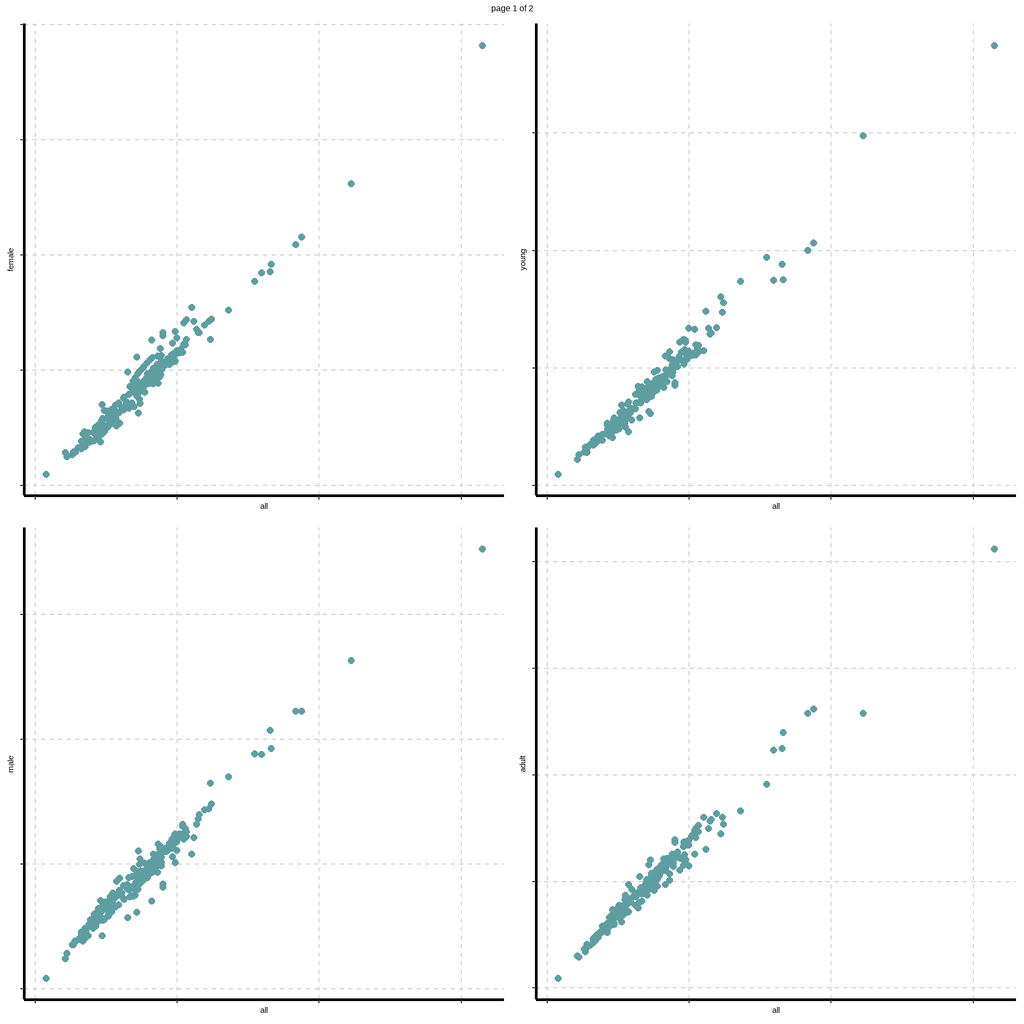

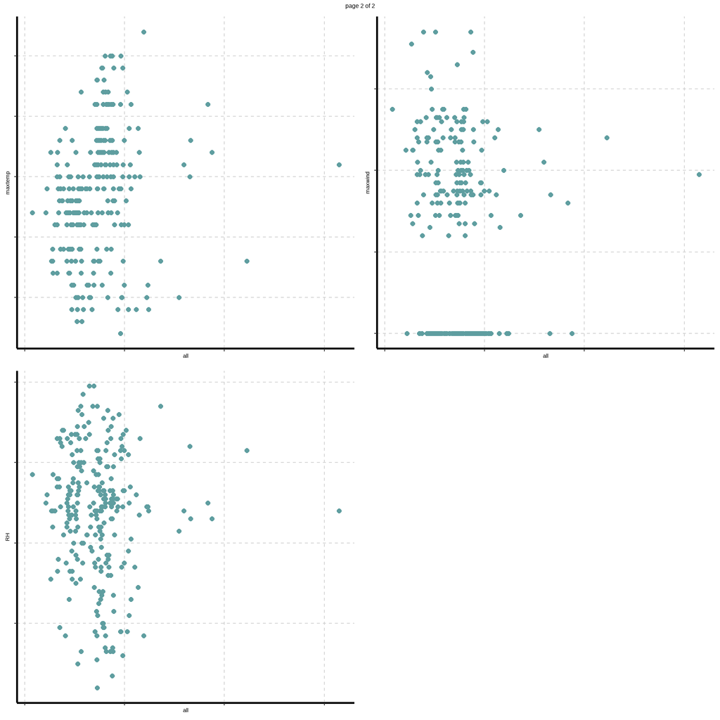

```r
ExpNumViz(data,target=Target,nlim=5,fname=NULL,col=NULL,theme=theme,Page=c(2,2),sample=sn)
```

```r
ExpNumStat(data,by="GA",gp=Target,MesofShape=2,Outlier=FALSE,round=2,dcast=T,val="cor")
```

| Stat | Vname | all |
| --- | --- | --- |
| cor | RH | -0.05 |
| cor | adult | 0.99 |
| cor | all | 1.00 |
| cor | female | 0.98 |
| cor | male | 0.98 |
| cor | maxtemp | 0.19 |
| cor | maxwind | -0.08 |
| cor | young | 0.99 |

### 4. Summary of categorical variables

Summary of categorical variables

- frequency for all categorical independent variables

```r
ExpCTable(data,margin=1,clim=10,nlim=5,round=2,per=T)
```

| Variable | Valid | Frequency | Percent | CumPercent |
| --- | --- | --- | --- | --- |
| weather | Rain | 57 | 22.18 | 22.18 |
| weather | Sunny | 200 | 77.82 | 100.00 |
| weather | TOTAL | 257 | NA | NA |

- frequency for all categorical independent variables by descretized **all**

```r
##bin=4, descretized 4 categories based on quantiles
ExpCTable(data,Target=Target,margin=1,clim=10,nlim=5,round=2,bin=4,per=T)
```

| VARIABLE | CATEGORY | Number | all:(360,4.22e+03] | all:(4.22e+03,8.06e+03] | all:(8.06e+03,1.19e+04] | all:(1.19e+04,1.58e+04] | TOTAL |
| --- | --- | --- | --- | --- | --- | --- | --- |
| weather | Rain | nn | 45.00 | 10.00 | 2 | 0 | 57.00 |
| weather | Sunny | nn | 142.00 | 54.00 | 3 | 1 | 200.00 |
| weather | TOTAL | nn | 187.00 | 64.00 | 5 | 1 | 257.00 |
| weather | Rain | % | 24.06 | 15.62 | 40 | 0 | 22.18 |
| weather | Sunny | % | 75.94 | 84.38 | 60 | 100 | 77.82 |
| weather | TOTAL | % | 100.00 | 100.00 | 100 | 100 | 100.00 |

### 5. Distributions of Categorical variables

Graphical representation of all Categorical variables

- Bar plot (Univariate)

Bar plot with vertical or horizontal bars for all categorical variables

```
## $`0`
```

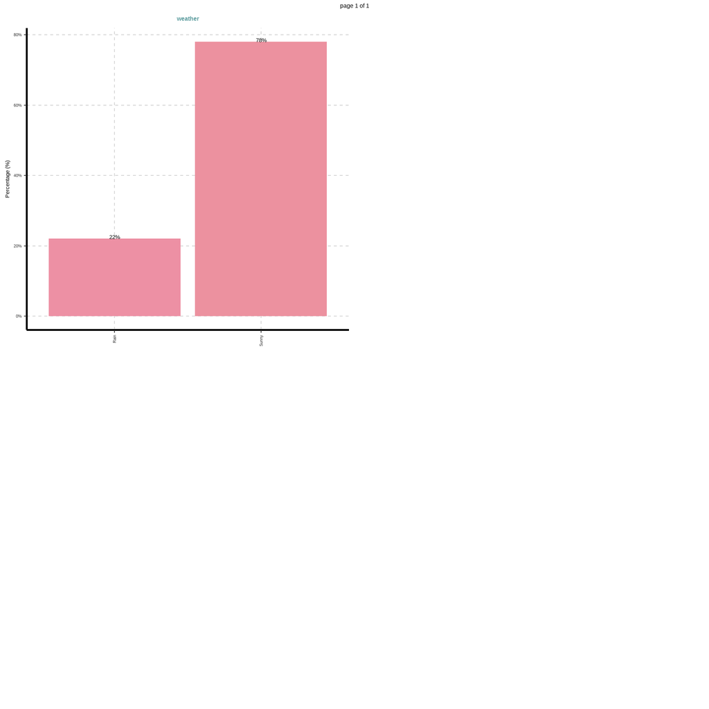

```r
ExpCatViz(data,clim=10,margin=2,theme=theme,Page = c(2,2),sample=sc)
```